# Project Report on Open Psychometric Data Analysis

Charles Yang, Bennet Brosseau, Carter Wunsch, Nicholas Heger, Isaac Tegeler

11/19/2020

# Background and Questions Raised

**Psychological traits may point toward a stronger vocabulary. This has applications for teaching and further research**

1. How do answers to each supplemental question relate to the vocabulary?
2. How do demographics affect the vocabulary?
3. Which questions were the hardest?
4. How does childhood living region correlate with vocabulary?
5. Which supplemental questions were similar to others?
6. How does education level affect vocabulary?

# Data Acquisition/Preparation/Wrangling

- Data imported from [Open Psychometrics](http://openpsychometrics.org/_rawdata/VIQT_data.zip)
- .csv file was tab-delimited, so was read into R like a .tsv
- Question answers were in binary, so they were treated as their decimal equivalent
- Changed several columns to numeric type
- Demographics mapped from their code to actual value (IE: Urban, Education)
- Created and merged separate table with correct answers to each vocab question

# Visualization

## Heatmap for question 5

#### We can see some supplemental questions correlate with each other, meaning we can group them by personality indications

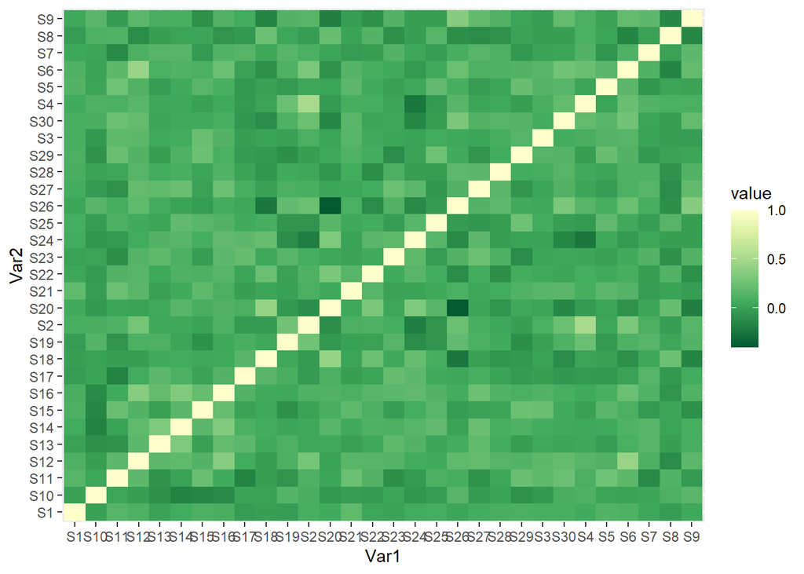

```r
x <- data %>% select(S1:S30)

c <- cor(x)
c <- data.frame(Var1 = row.names(c), c)
c <- c %>% pivot_longer(cols=S1:S30, names_to="Var2", values_to="value")

ggplot(c,aes(x=Var1, y=Var2, fill=value)) + geom_tile() + scale_fill_distiller(palette='YlGn')
```

#### People who do the bare minimum to get by tend to have lower scores

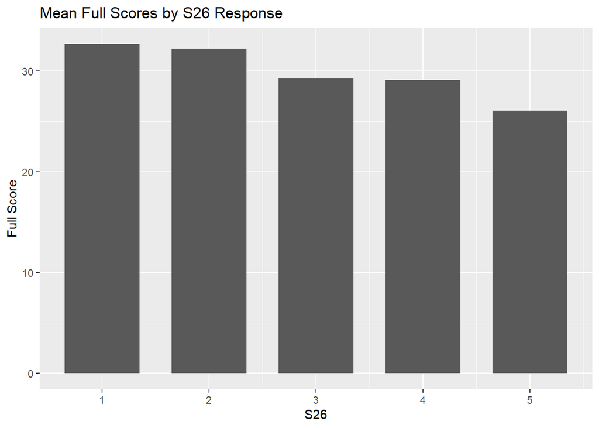

```r
data %>%
  group_by(S26) %>%
  summarise(`Full Score`=mean(score_full), .groups="drop") %>%
  filter(S26 > 0) %>%
  ggplot(aes(x=S26, y=`Full Score`)) +
  geom_bar(stat="identity", width=.7) +
  ggtitle("Mean Full Scores by S26 Response")
```

#### It is clear that more educated individuals tend to have higher vocabulary.

```r
data$education <- recode(data$education, `1`="< HS", `2`="HS", `3`="UNI", `4`="GRAD") %>% factor(levels=c("< HS", "HS", "UNI", "GRAD"))
```

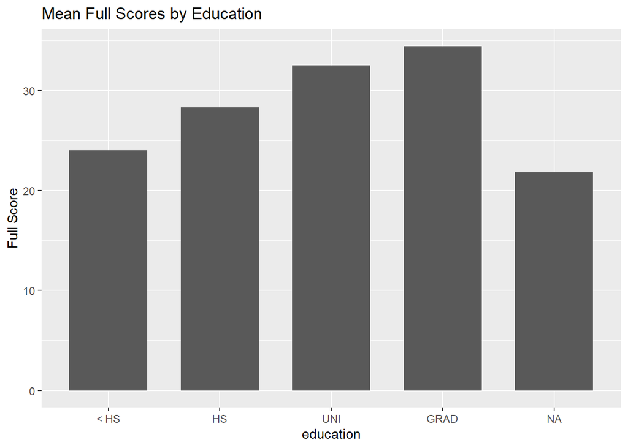

```r
data %>%
  group_by(education) %>%
  summarise(`Full Score`=mean(score_full), .groups="drop") %>%
  ggplot(aes(x=education, y=`Full Score`)) +
  geom_bar(stat="identity", width=.7) +
  ggtitle("Mean Full Scores by Education")
```

#### Native English speakers clearly performed better in an English vocabular test.

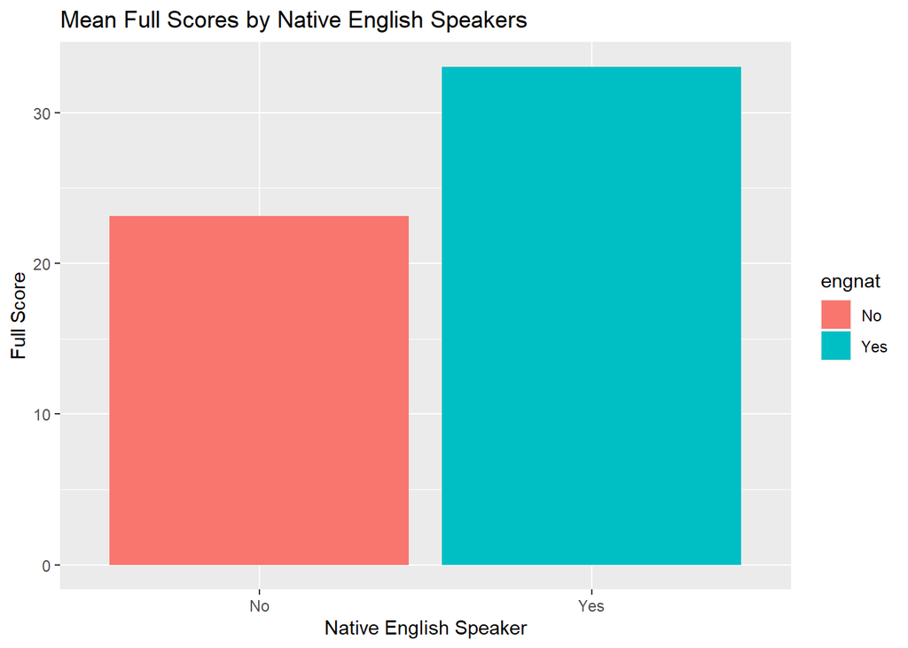

```r
group_by(data, engnat) %>%
  summarise(`Full Score` = mean(score_full), .groups = 'drop') %>%
  filter(engnat > 0) %>%
  mutate(engnat = ifelse(engnat == 1, "Yes", "No")) %>%
  ggplot(aes(x = engnat, y = `Full Score`, fill = engnat)) +
  geom_bar(stat = 'identity') +
  ggtitle("Mean Full Scores by Native English Speakers") +
  xlab("Native English Speaker")
```

#### There doesn’t seem to be much of a relationship with Gender and Vocabulary

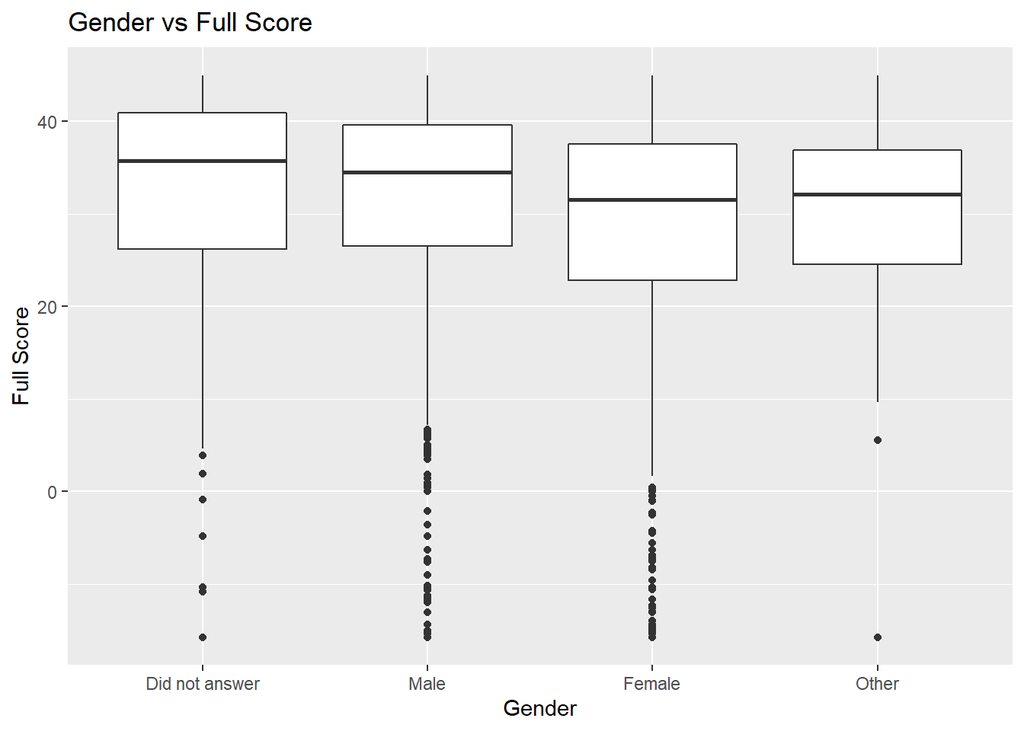

```r
dataGender <- data
dataGender$gender <- as.factor(dataGender$gender)
levels(dataGender$gender)[levels(dataGender$gender)==0] <- 'Did not answer'
levels(dataGender$gender)[levels(dataGender$gender)==1] <- 'Male'
levels(dataGender$gender)[levels(dataGender$gender)==2] <- 'Female'
levels(dataGender$gender)[levels(dataGender$gender)==3] <- 'Other'
ggplot(dataGender, aes(x=gender, y=score_full)) + geom_boxplot() + ggtitle('Gender vs Full Score') + xlab('Gender') + ylab('Full Score')
```

#### Age makes you wiser, at least in terms of vocabulary

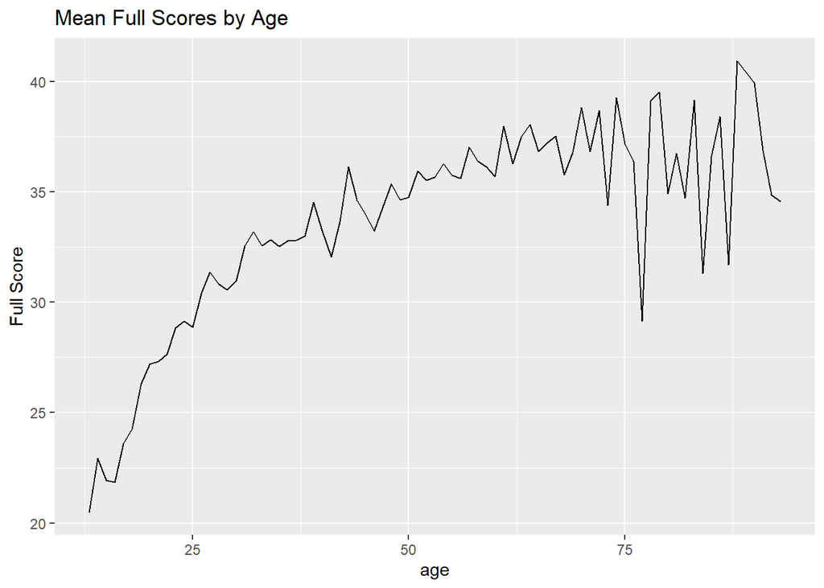

```r
data %>%
  group_by(age) %>%
  summarise(`Full Score`=mean(score_full), .groups="drop") %>%
  filter(age < 100) %>%
  ggplot(aes(x=age, y=`Full Score`)) +
  geom_line(stat="identity", width=.7) +
  ggtitle("Mean Full Scores by Age")
```